# Random causal forest: Effect on Confirmatory Typing

Hiroki Kato

Last updated on 3月 07, 2024

# 返信タイミングと患者都合中断

## Logit Regression

```r
dt <- subset(rct$data, positive == 1)
mod <- glm(exg_stop_test ~ days_reply, data = dt, family = binomial())
summary(mod)
```

```
##
## Call:
## glm(formula = exg_stop_test ~ days_reply, family = binomial(),
##     data = dt)
##
## Coefficients:
##              Estimate Std. Error z value Pr(>|z|)
## (Intercept) -2.792603   0.089019 -31.371  < 2e-16 ***
## days_reply   0.048180   0.007381   6.527  6.7e-11 ***
## ---
## Signif. codes:  0 '***' 0.001 '**' 0.01 '*' 0.05 '.' 0.1 ' ' 1
##
## (Dispersion parameter for binomial family taken to be 1)
##
##     Null deviance: 3703.5  on 6141  degrees of freedom
## Residual deviance: 3664.1  on 6140  degrees of freedom
## AIC: 3668.1
##
## Number of Fisher Scoring iterations: 5
```

## Fitted Lines

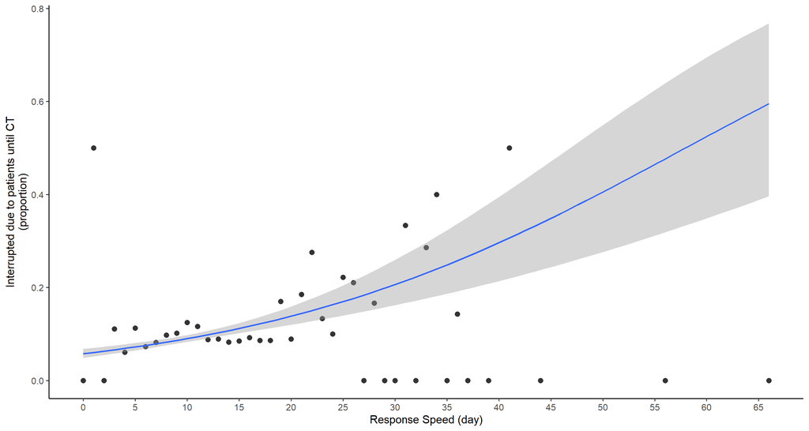

Relationshipt between Response Speed and Interruption due to Patients. Note: Fitted line represents the prediction of logit regression.

# Primary Outcomes

## 回帰分析

### Full Sample (LPM)

Linear Probability Model of Primary Outcomes

|  | Reply (1) | Reply (2) | Intention Positive (3) | Intention Positive (4) | CT (5) | CT (6) |
| --- | --- | --- | --- | --- | --- | --- |
| Treatment B | 0.013 | 0.017* | 0.023* | 0.023* | 0.031*** | 0.031*** |
|  | (0.009) | (0.009) | (0.013) | (0.014) | (0.011) | (0.012) |
| Treatment C | -0.004 | 0.005 | -0.004 | -0.002 | 0.012 | 0.011 |
|  | (0.009) | (0.009) | (0.014) | (0.014) | (0.012) | (0.012) |
| Treatment D | 0.008 | 0.008 | 0.006 | 0.007 | 0.024** | 0.026** |
|  | (0.009) | (0.009) | (0.014) | (0.014) | (0.012) | (0.012) |
| Control average | 0.8769 | 0.8769 | 0.5491 | 0.5491 | 0.2225 | 0.2225 |
| Covariates |  | X |  | X |  | X |
| Num.Obs. | 11049 | 11049 | 11049 | 11049 | 11049 | 11049 |

* p < 0.1, ** p < 0.05, *** p < 0.01  
Notes: * p < 0.1, ** p < 0.05, *** p < 0.01. The robust standard errors are in parentheses. Covariates are gender, squared polynomial of age, number of past coordinations, number of hospitals per 10 square kilometers, number of hospitals with PBSC collection per 10 square kilometers, number of hospitals with BM collection per 10 square kilometers, month dummies, and week dummies.

### Full Sample (Logit)

Logit Model of Primary Outcomes

|  | Reply (1) | Reply (2) | Intention Positive (3) | Intention Positive (4) | CT (5) | CT (6) |
| --- | --- | --- | --- | --- | --- | --- |
| Treatment B | 1.131 | 1.174 | 1.098 | 1.099 | 1.187 | 1.191 |
|  | [0.960, 1.333] | [0.990, 1.392] | [0.988, 1.221] | [0.983, 1.227] | [1.048, 1.344] | [1.047, 1.355] |
| Treatment C | 0.962 | 1.043 | 0.983 | 0.992 | 1.070 | 1.070 |
|  | [0.817, 1.133] | [0.877, 1.241] | [0.881, 1.095] | [0.884, 1.114] | [0.941, 1.217] | [0.933, 1.227] |
| Treatment D | 1.078 | 1.079 | 1.024 | 1.029 | 1.143 | 1.162 |
|  | [0.913, 1.274] | [0.906, 1.284] | [0.919, 1.142] | [0.918, 1.153] | [1.006, 1.299] | [1.017, 1.328] |
| Covariates |  | X |  | X |  | X |
| Num.Obs. | 11049 | 11049 | 11049 | 11049 | 11049 | 11049 |
| Log.Lik. | -4022.045 | -3848.179 | -7586.840 | -7415.644 | -6083.783 | -5942.333 |

* p < 0.1, ** p < 0.05, *** p < 0.01  
Notes: We show odds ratios and associated 95 percent confidential intervals in square brackets. Covariates are gender, squared polynomial of (demeaned) age, number of past coordinations, number of hospitals per 10 square kilometers, number of hospitals with PBSC collection per 10 square kilometers, number of hospitals with BM collection per 10 square kilometers, month dummies, and week dummies.

### Subsample (LPM)

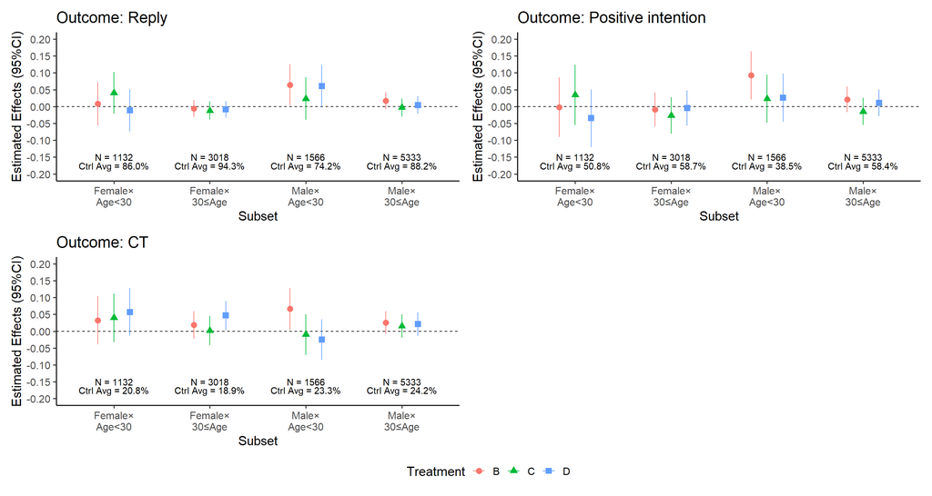

Subsample Analysis

## Random Causal Forest

### 返信

#### Boxplot

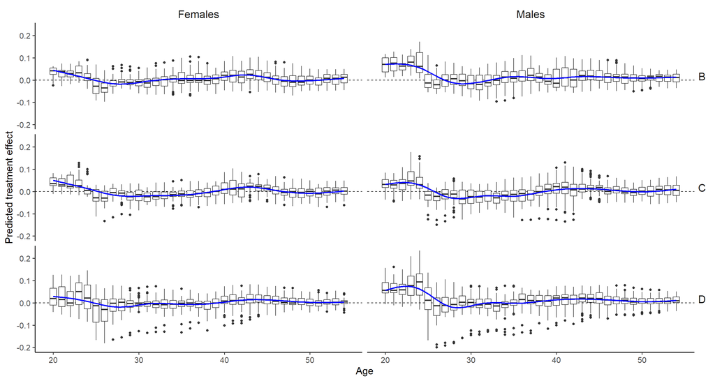

Box plot of Predicted Treatment Effect by Age, Gender, and Treatments (Reply)

#### CATE

Conditional Average Treatment Effect Estimated by RCF (Reply)

Female

Male

Age < 30

30 < Age

Age < 30

30 < Age

B

-0.0068

-0.0022

0.0545

0.0116

(0.0332)

(0.0147)

(0.0351)

(0.0141)

C

0.0154

-0.0053

0.0001

-0.0006

(0.0322)

(0.0155)

(0.0360)

(0.0149)

D

-0.0222

-0.0008

0.0495

0.0089

(0.0351)

(0.0149)

(0.0349)

(0.0146)

Notes: * p < 0.1, ** p < 0.05, *** p < 0.01. Standard errors are in parentheses. See Athey and Wager (2019) for estimation method of conditional average treatment effect (CATE). Since these estimates are asymptotically normal, we calculate z-score under the null hypothesis that CATE is zero, and obtain p-value.

### 提供意向

#### Boxplot

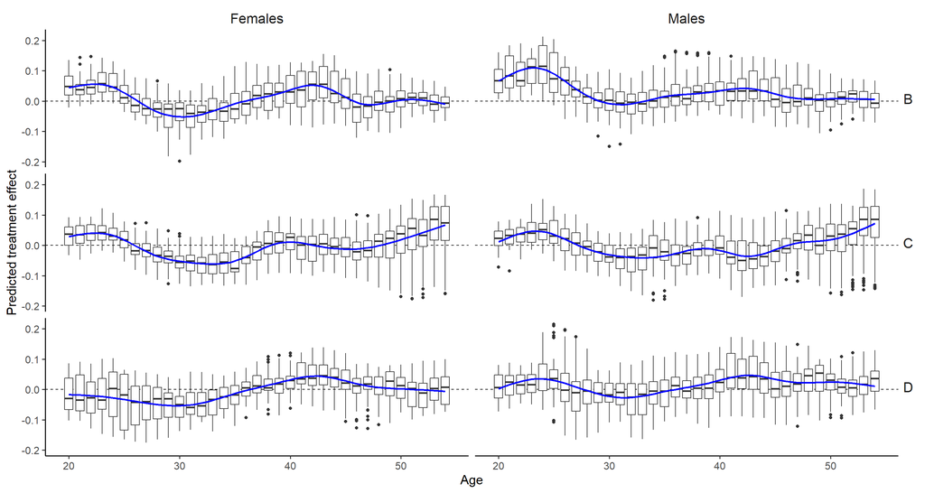

Box plot of Predicted Treatment Effect by Age, Gender, and Treatments (Positive Intention)

#### CATE

Conditional Average Treatment Effect Estimated by RCF (Positive Intention)

Female

Male

Age < 30

30 < Age

Age < 30

30 < Age

B

-0.0117

-0.0086

0.1308***

0.0210

(0.0494)

(0.0288)

(0.0411)

(0.0216)

C

0.0424

-0.0156

0.0496

-0.0125

(0.0500)

(0.0300)

(0.0421)

(0.0230)

D

-0.0617

0.0083

0.0471

0.0236

(0.0503)

(0.0293)

(0.0407)

(0.0223)

Notes: * p < 0.1, ** p < 0.05, *** p < 0.01. Standard errors are in parentheses. See Athey and Wager (2019) for estimation method of conditional average treatment effect (CATE). Since these estimates are asymptotically normal, we calculate z-score under the null hypothesis that CATE is zero, and obtain p-value.

### 確認検査

#### Boxplot

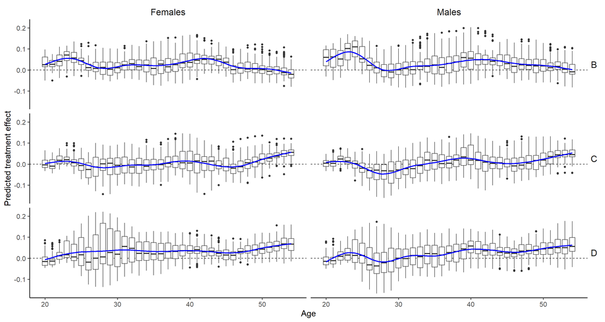

Box plot of Predicted Treatment Effect by Age, Gender, and Treatments (Confirmatory Typing)

#### CATE

Conditional Average Treatment Effect Estimated by RCF (Confirmatroy Typing)

Female

Male

Age < 30

30 < Age

Age < 30

30 < Age

B

0.0450

0.0165

0.0848**

0.0384**

(0.0401)

(0.0233)

(0.0371)

(0.0187)

C

0.0494

-0.0013

-0.0030

0.0283

(0.0405)

(0.0244)

(0.0360)

(0.0195)

D

0.0668

0.0396

-0.0206

0.0411**

(0.0417)

(0.0245)

(0.0337)

(0.0196)

Notes: * p < 0.1, ** p < 0.05, *** p < 0.01. Standard errors are in parentheses. See Athey and Wager (2019) for estimation method of conditional average treatment effect (CATE). Since these estimates are asymptotically normal, we calculate z-score under the null hypothesis that CATE is zero, and obtain p-value.

# Secondary Outcomes

## 回帰分析

### Full Sample (LPM)

Linear Probability Model of Secondary Outcomes

|  | Candidate (1) | Candidate (2) | Consent (3) | Consent (4) | Donation (5) | Donation (6) |
| --- | --- | --- | --- | --- | --- | --- |
| Treatment B | 0.002 | -0.001 | 0.003 | 0.000 | 0.001 | -0.001 |
|  | (0.007) | (0.007) | (0.006) | (0.006) | (0.006) | (0.006) |
| Treatment C | -0.001 | -0.003 | 0.001 | -0.002 | 0.000 | -0.002 |
|  | (0.007) | (0.007) | (0.006) | (0.007) | (0.006) | (0.006) |
| Treatment D | 0.005 | 0.005 | 0.006 | 0.006 | 0.001 | 0.000 |
|  | (0.007) | (0.007) | (0.006) | (0.007) | (0.006) | (0.006) |
| Control average | 0.0619 | 0.0619 | 0.0544 | 0.0544 | 0.0450 | 0.0450 |
| Covariates |  | X |  | X |  | X |
| Num.Obs. | 11049 | 11049 | 11049 | 11049 | 11049 | 11049 |

* p < 0.1, ** p < 0.05, *** p < 0.01  
Notes: * p < 0.1, ** p < 0.05, *** p < 0.01. The robust standard errors are in parentheses. Covariates are gender, squared polynomial of age, number of past coordinations, number of hospitals per 10 square kilometers, number of hospitals with PBSC collection per 10 square kilometers, number of hospitals with BM collection per 10 square kilometers, month dummies, and week dummies.

### Full Sample (Logit)

Logit Model of Secondary Outcomes

|  | Candidate (1) | Candidate (2) | Consent (3) | Consent (4) | Donation (5) | Donation (6) |
| --- | --- | --- | --- | --- | --- | --- |
| Treatment B | 1.028 | 0.987 | 1.050 | 1.001 | 1.028 | 0.975 |
|  | [0.827, 1.277] | [0.787, 1.237] | [0.834, 1.321] | [0.788, 1.272] | [0.799, 1.324] | [0.749, 1.267] |
| Treatment C | 0.988 | 0.942 | 1.011 | 0.962 | 1.004 | 0.950 |
|  | [0.789, 1.238] | [0.743, 1.194] | [0.797, 1.283] | [0.748, 1.238] | [0.773, 1.302] | [0.721, 1.251] |
| Treatment D | 1.086 | 1.086 | 1.122 | 1.118 | 1.017 | 1.007 |
|  | [0.871, 1.354] | [0.865, 1.364] | [0.889, 1.416] | [0.879, 1.422] | [0.784, 1.319] | [0.770, 1.316] |
| Covariates |  | X |  | X |  | X |
| Num.Obs. | 11049 | 11049 | 11049 | 11049 | 11049 | 11049 |
| Log.Lik. | -2610.914 | -2548.022 | -2410.035 | -2348.250 | -2045.363 | -2001.995 |

* p < 0.1, ** p < 0.05, *** p < 0.01  
Notes: We show odds ratios and associated 95 percent confidential intervals in square brackets. Covariates are gender, squared polynomial of (demeaned) age, number of past coordinations, number of hospitals per 10 square kilometers, number of hospitals with PBSC collection per 10 square kilometers, number of hospitals with BM collection per 10 square kilometers, month dummies, and week dummies.

### Subsample (LPM)

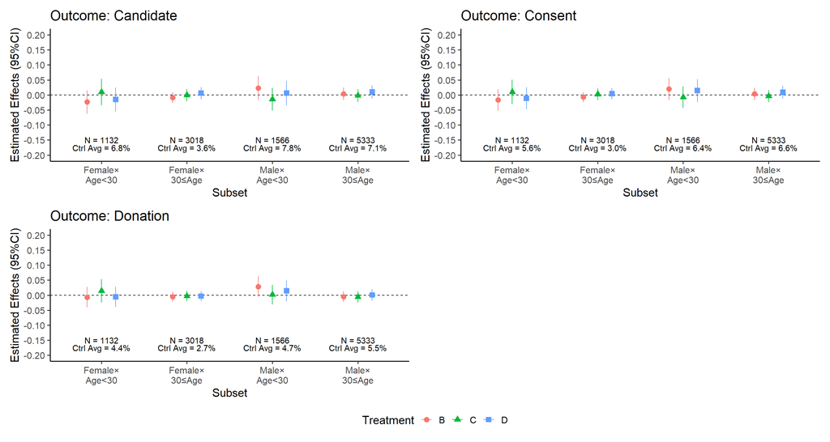

Subsample Analysis